# Objective 1 — Initial filtering

Macrogenetics of US freshwater fishes

## Purpose

This document filters the MacroPopGen species (`spec_tab`) and population (`pop_tab`) tables down to freshwater-breeding fishes sampled in the contiguous United States, and writes `GenDiv_filtered.csv` for downstream Objective 1 analyses.

## Setup

```r
library(here)      # project-relative paths
library(readxl)    # read_xlsx()
library(dplyr)
library(sf)
library(tigris)    # state boundaries for the map
library(ggplot2)
library(knitr)     # kable() for the filtering summary

sf::sf_use_s2(FALSE)
options(tigris_use_cache = TRUE)  # avoid re-downloading boundaries on each render

# Formats counts for inline reporting, e.g. 1,304
fmt <- function(x) format(x, big.mark = ",")
```

```r
path_spec <- here("Data", "external", "spec_tab_v2025-03-31.xlsx")
path_pop  <- here("Data", "external", "pop_tab_v2025-03-31.xlsx")
path_out  <- here("Data", "interim", "GenDiv_filtered.csv")
```

## Species table

```r
sp_raw <- read_xlsx(path_spec)
```

The species table contains **1,480** species–study records (one row per `Study_id`).

### Step 1 — Fishes only

```r
sp_fish <- sp_raw |>
  filter(Life_form == "Fishes")
```

Keeping `Life_form == "Fishes"` retains **329** records and removes **1,151** (77.8%).

### Step 2 — Freshwater breeders, excluding bull shark

```r
sp_fw <- sp_fish |>
  filter(Habitat_breeding == "Freshwater")

# Bull shark (Carcharhinus leucas) is coded as a freshwater breeder but is a
# marine/euryhaline elasmobranch. Excluded by its stable species ID rather than
# by common name, which could change between EOL versions.
excluded_species <- c("CALE")  # Carcharhinus leucas

sp <- sp_fw |>
  filter(!Spec_id %in% excluded_species)
```

Keeping `Habitat_breeding == "Freshwater"` removes **75** marine-breeding records, leaving 254. Dropping bull shark removes a further **1**, leaving **253** records covering 151 species.

## Population table

```r
pop_raw <- read_xlsx(path_pop)

# Used only for reporting: how many rows at each step belong to the
# freshwater fish studies retained above (the filters themselves are
# applied to all taxa, as in the original script).
n_fish <- function(df) sum(df$Study_id %in% sp$Study_id)
```

The population table has **19,174** populations across all taxa, of which **3,713** belong to the 253 retained fish studies.

### Step 3 — United States only

```r
pop_usa <- pop_raw |>
  filter(Geog_1 == "United States of America")
```

Restricting to `Geog_1 == "United States of America"` keeps 4,967 populations (all taxa), removing 14,207. For the fish studies this keeps **1,427** and removes **2,286** non-US populations.

### Step 4 — Latitude 25–50° N (contiguous US proxy)

```r
# Latitude window drops Alaska (and Hawaii). Preferred over a spatial
# intersection with state polygons, which would also drop real US sites in
# open Great Lakes and Delaware Bay waters.
pop_lat <- pop_usa |>
  filter(Latitude < 50, Latitude > 25)
```

The latitude window removes 420 populations across all taxa; for fish studies it removes **122** (Alaska), leaving **1,305**.

### Step 5 — Remove mislabelled populations

```r
# Populations whose Geog_1 says USA but whose coordinates are outside it.
# COCL-1-28 (Geog_2 "O3", 47.87 N, 75.54 W) is in Quebec; the other 29
# populations in study COCL-1 are labelled Canada. This replaces the earlier
# bounding box (>= 46 N, 80-72 W), which removed only this population.
mislabelled_pops <- c("COCL-1-28")

pop <- pop_lat |>
  filter(!Pop_id %in% mislabelled_pops)

removed_mislabelled <- anti_join(pop_lat, pop, by = "Pop_id")
stopifnot(
  "A listed mislabelled Pop_id was not found" =
    nrow(removed_mislabelled) == length(mislabelled_pops)
)
```

This removes 1 population(s), 1 of them from fish studies:

```r
removed_mislabelled |>
  select(Study_id, Pop_id, Geog_1, Geog_2, Latitude, Longitude)
```

| Study_id | Pop_id | Geog_1 | Geog_2 | Latitude | Longitude |
| --- | --- | --- | --- | --- | --- |
| COCL-1 | COCL-1-28 | United States of America | O3 | 47.86583 | -75.53607 |

This leaves **4,546** populations (all taxa), of which **1,304** belong to fish studies.

## Join species and populations

```r
dat <- inner_join(
  sp, pop,
  by = c("Study_id", "Spec_id"),
  relationship = "one-to-many"
)
```

The inner join keeps **1,304** populations from **110** studies and **71** species. Of the 253 freshwater fish studies, 143 have no populations in the filtered US data and drop out here.

### Sanity checks

```r
stopifnot(
  "Pop_id is not unique"             = !anyDuplicated(dat$Pop_id),
  "Fish study populations dropped by the species-ID join" =
    nrow(dat) == n_fish(pop),
  "Missing He values"                = !anyNA(dat$He),
  "Missing coordinates"              = !anyNA(dat$Latitude) && !anyNA(dat$Longitude),
  "He outside [0, 1]"                = all(between(dat$He, 0, 1))
)
```

### Filtering summary

```r
filter_log <- tibble::tribble(
  ~step, ~table, ~n_after,
  "Raw species table",               "species", nrow(sp_raw),
  "1. Fishes only",                  "species", nrow(sp_fish),
  "2a. Freshwater breeding",         "species", nrow(sp_fw),
  "2b. Drop bull shark",             "species", nrow(sp),
  "Raw population table (fish)",     "pops",    n_fish(pop_raw),
  "3. United States",                "pops",    n_fish(pop_usa),
  "4. Latitude 25–50° N",            "pops",    n_fish(pop_lat),
  "5. Mislabelled populations",      "pops",    n_fish(pop),
  "Joined (final)",                  "pops",    nrow(dat)
) |>
  group_by(table) |>
  mutate(n_removed = lag(n_after) - n_after) |>
  ungroup()

kable(filter_log, format.args = list(big.mark = ","))
```

| step | table | n_after | n_removed |
| --- | --- | --- | --- |
| Raw species table | species | 1,480 | NA |
| 1. Fishes only | species | 329 | 1,151 |
| 2a. Freshwater breeding | species | 254 | 75 |
| 2b. Drop bull shark | species | 253 | 1 |
| Raw population table (fish) | pops | 3,713 | NA |
| 3. United States | pops | 1,427 | 2,286 |
| 4. Latitude 25–50° N | pops | 1,305 | 122 |
| 5. Mislabelled populations | pops | 1,304 | 1 |
| Joined (final) | pops | 1,304 | 0 |

Population counts in the summary are restricted to rows belonging to the retained fish studies so the steps are comparable.

## Map of retained populations

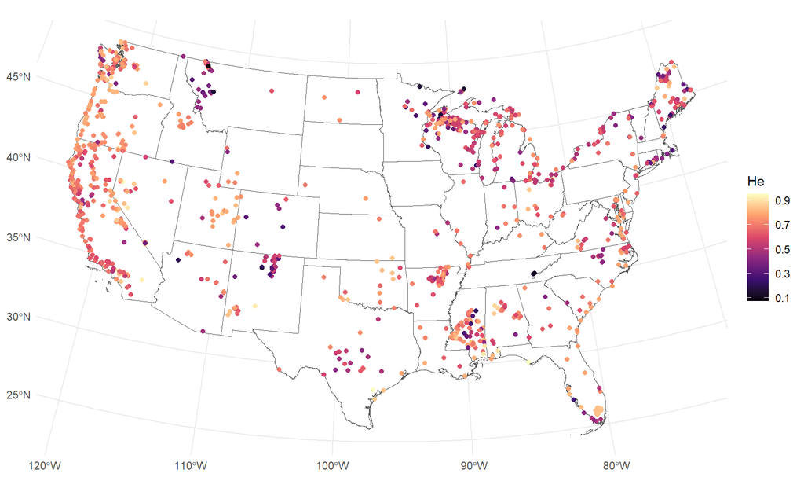

```r
# Boundary year pinned so the map doesn't change when tigris updates its default
states <- tigris::states(cb = TRUE, year = 2023, progress_bar = FALSE) |>
  filter(!STUSPS %in% c("HI", "PR", "AK", "MP", "GU", "AS", "VI")) |>
  st_transform(crs = 5070)

dat_sf <- st_as_sf(dat, coords = c("Longitude", "Latitude"), crs = 4326) |>
  st_transform(crs = 5070)

ggplot() +
  geom_sf(data = states, fill = "white") +
  geom_sf(data = dat_sf, aes(color = He)) +
  scale_color_viridis_c(
    option = "magma",
    limits = range(dat$He),
    breaks = seq(0.1, 0.9, by = 0.2)  # spans the observed range (~0.07-0.95)
  ) +
  theme_minimal()
```

## Write output

```r
output_cols <- c(
  "Data_source", "Spec_id", "Study_id", "Spec_Latin_GenDivRange", "DOI_study",
  "DOI_data", "Spec_Latin_publication", "N_pops", "N_loci", "Spec_Latin_GBIF",
  "Genus_GBIF", "Family_GBIF", "Order_GBIF", "Class_GBIF", "Phylum_GBIF",
  "Spec_common_EOL", "BIOME", "Habitat_fishbase", "Habitat_breeding",
  "Habitat_adulthood", "Pop_id", "Geog_2", "Latitude", "Longitude",
  "N", "A", "A_mean", "A_tot", "A_eff", "A_private", "N_genot", "Ar", "Ho", "He"
)

filt_dat <- dat |>
  select(all_of(output_cols))

write.csv(filt_dat, path_out, row.names = FALSE)
```

Wrote **1,304** rows × 34 columns to GenDiv_filtered.csv.